# Detroit-Part 1

Hong Tai

2/13/2022

```r
library(tidyverse)
library(lubridate)
library(tidyverse)
library(DBI)
library(dbplyr)
library(sf)
```

Load data # database sales

```r
con <- DBI::dbConnect(RSQLite::SQLite(), "detroit.sqlite")
# sales tbl
dplyr::tbl(con, 'sales')
```

| parcel_num | sale_date | sale_price | grantor | grantee | sale_terms | ecf | property_c |
| --- | --- | --- | --- | --- | --- | --- | --- |
| 22059361-5 | 2011-08-30 | 500 | WAYNE COUNTY TREASURER | DETROIT LAND BANK AUTHORITY | EXEMPT/GOVT | 7185A | 402 |
| 21065621. | 2012-03-15 | 1 | CITY OF DETROIT | DETROIT LAND BANK AUTHORITY | NO CONSIDERATION | 3096B | 402 |
| 01000616.001 | 2011-02-04 | 243421 | WAYNE COUNTY SHERIFF | FANNIE MAE | FORECLOSURE/FORFEIT | CNDOE | 403 |
| 01000616.001 | 2011-09-09 | 155100 | FANNIE MAE | BIDWELL, BRAD & GORDON, KYLE | BANK SALE NOT USED | CNDOE | 403 |
| 01000617.007 | 2011-11-12 | 264323 | WAYNE COUNTY SHERIFF | FEDERAL HOME LOAN MORTGAGE | NO CONSIDERATION | CNDOE | 403 |
| 01000617.007 | 2012-04-26 | 122500 | FEDERAL HOME LOAN MORTGAGE | FORD, CHRISTOPHER & FRASIER, MEGAN | BANK SALE NOT USED | CNDOE | 403 |
| 01000617.009 | 2012-07-13 | 138000 | HUD | KINNI, VIJAYA | BANK SALE NOT USED | CNDOE | 403 |
| 01000617.024 | 2012-08-20 | 106000 | PUGH, CHARLES | SHAMROCK ACQUISITIONS LLC | NO CONSIDERATION | CNDOE | 403 |
| 01000617.025 | 2011-11-09 | 109000 | U S BANK NATIONAL ASSOCIATION | INNES, STEVEN | NO CONSIDERATION | CNDOE | 403 |
| 01000618.007 | 2011-10-24 | 83000 | LAKE TRUST CREDIT UNION | PETERSON, KENNETH | BANK SALE NOT USED | CNDOE | 403 |

[output cut: 990 more lines]

```r
# convert to tibble
sales <- dplyr::tbl(con, 'sales') %>% dplyr::collect()
# sql query
dplyr::tbl(con, 'sales') %>% count(year(sale_date))
```

| year(sale_date) | n |
| --- | --- |
| 2011 | 19854 |
| 2012 | 24480 |
| 2013 | 25955 |
| 2014 | 41359 |
| 2015 | 36765 |
| 2016 | 29524 |
| 2017 | 29347 |
| 2018 | 29956 |
| 2019 | 33025 |
| 2020 | 6285 |

```r
dplyr::tbl(con, 'sales') %>% count(year(sale_date)) %>% show_query()
```

```
## <SQL>
## SELECT `year(sale_date)`, COUNT(*) AS `n`
## FROM (SELECT `parcel_num`, `sale_date`, `sale_price`, `grantor`, `grantee`, `sale_terms`, `ecf`, `property_c`, CAST(STRFTIME('%Y', `sale_date`) AS NUMERIC) AS `year(sale_date)`
## FROM `sales`)
## GROUP BY `year(sale_date)`
```

```r
# add new clo year in sales
sales$year <- year(sales$sale_date)
```

Load data # database assessments

```r
# assessments tbl
dplyr::tbl(con, 'assessments')
```

| PARCELNO | propclass | ASSESSEDVALUE | TAXABLEVALUE | year |
| --- | --- | --- | --- | --- |
| 04990185.05 | 401 | 0 | 0 | 2011 |
| 08007238. | 401 | 44510 | 9166 | 2011 |
| 08007253.003L | 401 | 2997 | 2997 | 2011 |
| 08007253.002 | 401 | 3040 | 3040 | 2011 |
| 08000474.002L | 401 | 4871 | 4871 | 2011 |
| 08007239. | 401 | 6162 | 6162 | 2011 |
| 08007240. | 401 | 5621 | 5621 | 2011 |
| 08007253.001 | 401 | 2538 | 2538 | 2011 |
| 08007241. | 401 | 5704 | 5704 | 2011 |
| 08007252. | 401 | 3330 | 3330 | 2011 |

[output cut: 990 more lines]

```r
# convert to tibble
assessments <- dplyr::tbl(con, 'assessments') %>% dplyr::collect()
# sql query
dplyr::tbl(con, 'assessments') %>% count(year)
```

| year | n |
| --- | --- |
| 2011 | 316633 |
| 2012 | 316659 |
| 2013 | 314914 |
| 2014 | 316186 |
| 2015 | 323202 |
| 2016 | 324457 |
| 2017 | 346936 |
| 2018 | 347015 |
| 2019 | 349763 |
| 2020 | 349774 |

[output cut: 2 more lines]

```r
dplyr::tbl(con, 'assessments') %>% count(year) %>% show_query()
```

```
## <SQL>
## SELECT `year`, COUNT(*) AS `n`
## FROM `assessments`
## GROUP BY `year`
```

Load data # database parcels

```r
# parcels tbl
dplyr::tbl(con, 'parcels')
```

| OBJECTID | object_id | parcel_number | ward | address | council_district | zip_code | taxpayer_1 | taxpayer_2 | taxpayer_street | taxpayer_city | taxpayer_state | taxpayer_zip | property_class | property_class_desc | use_code | use_code_desc | tax_status | total_square_footage | total_acreage | frontage | depth | homestead_pre | nez | is_improved | num_bldgs | total_floor_area | style | year_built | sale_price | … |
| --- | --- | --- | --- | --- | --- | --- | --- | --- | --- | --- | --- | --- | --- | --- | --- | --- | --- | --- | --- | --- | --- | --- | --- | --- | --- | --- | --- | --- | --- | --- |
| 1 | 77483 | 06004253. | 06 | 1699 KENDALL | 2 | 48238 | DETROIT LAND BANK AUTHORITY | NA | 500 GRISWOLD STREET, SUITE 1200 | DETROIT | MI | 48226 | 402 | RESIDENTIAL VACANT | 00003 | VACANT RESIDENTIAL | CITY LAND BANK | 2513.00 | 0.058 | 25 | 100 | 0 | NA | 0 | 0 | NA | NA | NA | 0 | … |
| 2 | 77500 | 22038234. | 22 | 17555 STRATHMOOR | 2 | 48235 | JONES, DONNA | NA | 17555 STRATHMOOR | DETROIT | MI | 48235 | 401 | RESIDENTIAL | 41110 | SINGLE FAMILY | TAXABLE | 4400.00 | 0.101 | 40 | 110 | 100 | Outer Drive West - Hubbell (H038) | 1 | 1 | 1140 | SINGLE FAMILY | 1941 | 50000 | … |
| 3 | 77523 | 22034773. | 22 | 17592 ARDMORE | 2 | 48235 | GARLAND, PORTIA | NA | 17592 ARDMORE ST | DETROIT | MI | 48235-2603 | 401 | RESIDENTIAL | 41110 | SINGLE FAMILY | TAXABLE | 5663.00 | 0.130 | 42 | 135 | 100 | NA | 1 | 1 | 1325 | SINGLE FAMILY | 1940 | 120000 | … |
| 4 | 77533 | 22030567-8 | 22 | 18065 SCHAEFER | 2 | 48235 | WOODWARD, BERNADINE | NA | 18065 SCHAEFER HWY | DETROIT | MI | 48235-2633 | 401 | RESIDENTIAL | 41120 | HALF DUPLEX | TAXABLE | 3006.00 | 0.069 | 30 | 100 | 100 | NA | 1 | 1 | 960 | 1/2 DUPLEX | 1947 | 18500 | … |
| 5 | 77555 | 22036058. | 22 | 18451 FREELAND | 2 | 48235 | CAD HOLDINGS 3 LIMITED PARTNERSHIP | NA | 39111 SIX MILE RD STE 106 | LIVONIA | MI | 48152 | 401 | RESIDENTIAL | 41110 | SINGLE FAMILY | TAXABLE | 5175.00 | 0.119 | 40 | 129 | 0 | NA | 1 | 1 | 982 | SINGLE FAMILY | 1943 | 10100 | … |
| 6 | 77562 | 22035064. | 22 | 18315 ARDMORE | 2 | 48235 | AUSTIN, MOTIASHIA L | NA | 18315 ARDMORE | DETROIT | MI | 48235 | 401 | RESIDENTIAL | 41110 | SINGLE FAMILY | TAXABLE | 4746.00 | 0.109 | 37 | 129 | 100 | NA | 1 | 1 | 1365 | SINGLE FAMILY | 1948 | 11000 | … |
| 7 | 77574 | 22032799. | 22 | 18250 LESURE | 2 | 48235 | FARRIS, C & REID, S & T | NA | 18250 LESURE ST | DETROIT | MI | 48235-2520 | 401 | RESIDENTIAL | 41110 | SINGLE FAMILY | TAXABLE | 5175.00 | 0.119 | 40 | 129 | 100 | NA | 1 | 1 | 1201 | SINGLE FAMILY | 1948 | 18700 | … |
| 8 | 77619 | 22014026. | 22 | 14422 W MCNICHOLS | 2 | 48235 | EMES REALTY, LLC | NA | 26130 MARLOWE PLACE | OAK PARK | MI | 48237 | 201 | COMMERCIAL | 22410 | STORE-RETAIL | TAXABLE | 1999.00 | 0.046 | 20 | 100 | 0 | NA | 1 | 1 | 1300 | Stores - Retail | 1953 | 158000 | … |
| 9 | 77740 | 22031516. | 22 | 19318 TRACEY | 2 | 48235 | GIBSON, MONICA | NA | 19318 TRACEY | DETROIT | MI | 48235 | 401 | RESIDENTIAL | 41110 | SINGLE FAMILY | TAXABLE | 5314.00 | 0.122 | 41 | 130 | 100 | NA | 1 | 1 | 879 | SINGLE FAMILY | 1941 | 19200 | … |
| 10 | 77806 | 22036983. | 22 | 19756 MARK TWAIN | 2 | 48235 | DIXON, CHRISTINE | NA | 19756 MARK TWAIN ST | DETROIT | MI | 48235-1605 | 401 | RESIDENTIAL | 41110 | SINGLE FAMILY | TAXABLE | 5271.00 | 0.121 | 40 | 132 | 100 | NA | 1 | 1 | 1202 | SINGLE FAMILY | 1942 | 18250 | … |

[output cut: 990 more lines]

```r
# convert to tibble
parcels <- dplyr::tbl(con, 'parcels') %>% dplyr::collect()
# sql query
dplyr::tbl(con, 'parcels') %>% count(year(sale_date))
```

| year(sale_date) | n |
| --- | --- |
| NA | 380457 |
| -4713 | 314 |
| -4476 | 1 |
| 2621 | 218 |
| 5223 | 1 |
| 9244 | 273 |
| 9717 | 1 |

```r
dplyr::tbl(con, 'parcels') %>% count(year(sale_date)) %>% show_query()
```

```
## <SQL>
## SELECT `year(sale_date)`, COUNT(*) AS `n`
## FROM (SELECT `OBJECTID`, `object_id`, `parcel_number`, `ward`, `address`, `council_district`, `zip_code`, `taxpayer_1`, `taxpayer_2`, `taxpayer_street`, `taxpayer_city`, `taxpayer_state`, `taxpayer_zip`, `property_class`, `property_class_desc`, `use_code`, `use_code_desc`, `tax_status`, `total_sq…
## FROM `parcels`)
## GROUP BY `year(sale_date)`
```

Load data # database parcels_historic

```r
# parcels tbl
dplyr::tbl(con, 'parcels_historic')
```

| PARCELNO | PROPADDR | ZIPCODE | TAXPAYER1 | TAXPADDR | TAXPCITY | TAXPSTATE | TAXPZIP | propclass | TAXSTATUS | TOTALSQFT | TOTALACREAGE | FRONTAGE | PRE | SALEPRICE | SALEDATE | ASSESSEDVALUE | TAXABLEVALUE | RESBLDCOUNT | tax_year |
| --- | --- | --- | --- | --- | --- | --- | --- | --- | --- | --- | --- | --- | --- | --- | --- | --- | --- | --- | --- |
| 04002773 | 908 GLYNN CT | NA | JAMES, MARESA K | 908 GLYNN COURT | DETROIT | MI | 48202 | 401 | TAXABLE | 4.095000e+03 | 0.188 | 35.00 | NA | 72000 | 13305 | 30536 | 30536 | 1 | 2009 |
| 04002823 | 887 CALVERT | NA | BROWN, SHIRLEY | 887 CALVERT ST | DETROIT | MI | 48202-1207 | 401 | TAXABLE | 4.356000e+03 | 0.200 | 35.00 | NA | 1 | 11619 | 22914 | 22914 | 1 | 2009 |
| 04002774 | 902 GLYNN CT | NA | GEE, ELMER | 31325 ROAN DRIVE | WARREN | MI | 48093 | 401 | TAXABLE | 4.095000e+03 | 0.188 | 35.00 | NA | 3900 | 14098 | 23504 | 23504 | 1 | 2009 |
| 04002822 | 881 CALVERT | NA | BARNES, PAUL | 881 CALVERT ST | DETROIT | MI | 48202-1207 | 401 | TAXABLE | 4.356000e+03 | 0.200 | 35.00 | NA | 0 | NA | 21380 | 7559 | 1 | 2009 |
| 04002775 | 896 GLYNN CT | NA | WAYNE COUNTY INVENTORY | 400 MONROE ST 5TH FL | DETROIT | MI | 48226 | 401 | COUNTY OWNED | 4.095000e+03 | 0.188 | 35.00 | NA | 0 | 13512 | 0 | 0 | 0 | 2009 |
| 04002753 | 961 W BOSTON BLVD | NA | BROWN, CORA E | 961 W BOSTON BLVD | DETROIT | MI | 48202-1401 | 402 | TAXABLE | 8.233000e+03 | 0.378 | 49.22 | NA | 65000 | 5995 | 103888 | 70022 | 1 | 2009 |
| 16000590 | 5644 CHRISTIANCY | NA | LARA, CARLOS | 5644 CHRISTIANCY ST | DETROIT | MI | 48209-2102 | 401 | TAXABLE | 3.746000e+03 | 0.172 | 30.00 | NA | 12000 | 9435 | 22260 | 8906 | 1 | 2009 |
| 16015195 | 1015 CAVALRY | NA | SALINAS,DENISIA&MENDOZA,JOSE& MARIA | 1015 CAVALRY | DETROIT | MI | 48209 | 401 | TAXABLE | 4.487000e+03 | 0.206 | 30.00 | NA | 12970 | 13920 | 11291 | 11291 | 1 | 2009 |
| 16015044 | 1124 CAVALRY | NA | PORTER, KATHERINE D | 1128 CAVALRY ST | DETROIT | MI | 48209-2345 | 401 | TAXABLE | 1.612000e+03 | 0.074 | 13.50 | NA | 17 | 11323 | 241 | 240 | 0 | 2009 |
| 04002648 | 905 LONGFELLOW | NA | HARDAMON, ZINA | 905 LONGFELLOW | DETROIT | MI | 48208 | 401 | TAXABLE | 5.358000e+03 | 0.246 | 40.00 | NA | 183000 | 13256 | 45992 | 45992 | 1 | 2009 |

[output cut: 990 more lines]

```r
# convert to tibble
parcels_historic <- dplyr::tbl(con, 'parcels_historic') %>% dplyr::collect()
# sql query
dplyr::tbl(con, 'parcels_historic') %>% count(year(SALEDATE))
```

| year(SALEDATE) | n |
| --- | --- |
| NA | 102720 |
| -4713 | 501 |
| -4712 | 2484 |
| -4711 | 2751 |
| -4710 | 3018 |
| -4709 | 1323 |
| -4708 | 3041 |
| -4707 | 2309 |
| -4706 | 4744 |
| -4705 | 6907 |

[output cut: 32 more lines]

```r
dplyr::tbl(con, 'parcels_historic') %>% count(year(SALEDATE)) %>% show_query()
```

```
## <SQL>
## SELECT `year(SALEDATE)`, COUNT(*) AS `n`
## FROM (SELECT `PARCELNO`, `PROPADDR`, `ZIPCODE`, `TAXPAYER1`, `TAXPADDR`, `TAXPCITY`, `TAXPSTATE`, `TAXPZIP`, `propclass`, `TAXSTATUS`, `TOTALSQFT`, `TOTALACREAGE`, `FRONTAGE`, `PRE`, `SALEPRICE`, `SALEDATE`, `ASSESSEDVALUE`, `TAXABLEVALUE`, `RESBLDCOUNT`, `tax_year`, CAST(STRFTIME('%Y', `SALEDATE…
## FROM `parcels_historic`)
## GROUP BY `year(SALEDATE)`
```

Load data # database blight

```r
# parcels tbl
dplyr::tbl(con, 'blight')
```

| ticket_id | ticket_number | agency_name | violator_name | violation_street_number | violation_street_name | violation_zip_code | violator_id | mailing_address_str_number | mailing_address_str_name | city | state | zip_code | non_us_str_code | country | violation_date | ticket_issued_time | violation_code | violation_description | disposition | clean_up_cost | payment_amount | payment_date | payment_status | collection_status | violation_address | parcelno |
| --- | --- | --- | --- | --- | --- | --- | --- | --- | --- | --- | --- | --- | --- | --- | --- | --- | --- | --- | --- | --- | --- | --- | --- | --- | --- | --- |
| 18645 | 05001700DAH | Buildings, Safety Engineering & Env Department | Dean Byrd | 601 | KING | NA | 1614 | 599 | King | Det | MI | 48202 | NA | NA | 2005/01/13 00:00:00+00 | 1900/01/01 14:00:00 | 9-1-36(a) | Failure of owner to obtain certificate of compliance | Responsible by Default | NA | NA | NA | NA | NA | 601 KING | 03002390. |
| 18646 | 05001701DAH | Buildings, Safety Engineering & Env Department | Cynthia Roberts | 607 | KING | NA | 1615 | 18604 | Appoline | Det | MI | 48235 | NA | NA | 2005/01/14 00:00:00+00 | 1900/01/01 00:45:00 | 9-1-36(a) | Failure of owner to obtain certificate of compliance | Not responsible by City Dismissal | NA | NA | NA | NO PAYMENT DUE | NA | 607 KING | NA |
| 18648 | 05001703DAH | Buildings, Safety Engineering & Env Department | Dannny Barnes | 4066 | COLUMBUS | NA | 1617 | 4066 | Columbus | Det | MI | 48204 | NA | NA | 2005/01/14 00:00:00+00 | 1900/01/01 14:00:00 | 9-1-36(a) | Failure of owner to obtain certificate of compliance | Not responsible by Dismissal | NA | NA | NA | NO PAYMENT DUE | NA | 4066 COLUMBUS | 14002572. |
| 18649 | 05001704DAH | Buildings, Safety Engineering & Env Department | Gloria Seldon | 3005 | PASADENA | NA | 1618 | 3005 | Pasada | Det | MI | 48238 | NA | NA | 2005/01/14 00:00:00+00 | 1900/01/01 14:50:00 | 9-1-36(a) | Failure of owner to obtain certificate of compliance | Not responsible by City Dismissal | NA | NA | NA | NO PAYMENT DUE | NA | 3005 PASADENA | NA |
| 18650 | 05001705DAH | Buildings, Safety Engineering & Env Department | Bessie Thomas | 4024 | CLEMENTS | NA | 1619 | 20211 | Westmoreland | Det | MI | 48219 | NA | NA | 2005/01/14 00:00:00+00 | 1900/01/01 14:05:00 | 9-1-36(a) | Failure of owner to obtain certificate of compliance | Not responsible by City Dismissal | NA | NA | NA | NO PAYMENT DUE | NA | 4024 CLEMENTS | 14005602. |
| 18651 | 05001706DAH | Buildings, Safety Engineering & Env Department | Shams Algoro | 4017 | CLEMENTS | NA | 1620 | 16925 | Linwood | DEt | MI | 48221 | NA | NA | 2005/01/14 00:00:00+00 | 1900/01/01 14:25:00 | 9-1-36(a) | Failure of owner to obtain certificate of compliance | Not responsible by City Dismissal | NA | NA | NA | NO PAYMENT DUE | NA | 4017 CLEMENTS | 14005524. |
| 18652 | 05001707DAH | Buildings, Safety Engineering & Env Department | Aljay Adams | 3395 | PALMER | NA | 1621 | 3387 | E. Adams | Det | MI | 48221 | NA | NA | 2005/01/14 00:00:00+00 | 1900/01/01 15:10:00 | 9-1-36(a) | Failure of owner to obtain certificate of compliance | Responsible by Default | NA | NA | NA | NA | NA | 3395 PALMER | 13003490. |
| 18653 | 05001708DAH | Buildings, Safety Engineering & Env Department | na Garden Court Apt.s | 2900 | JEFFERSON | NA | 1622 | 2900 | E. Jefferson | Det | MI | 48207 | NA | NA | 2005/01/14 00:00:00+00 | 1900/01/01 15:15:00 | 9-1-36(a) | Failure of owner to obtain certificate of compliance | Responsible by Admission | NA | NA | 2005/02/22 08:43:00+00 | PAID IN FULL | NA | 2900 JEFFERSON | CONDO BUILDING |
| 18654 | 05001709DAH | Buildings, Safety Engineering & Env Department | na JMC Manag. | 69 | SEWARD | NA | 1623 | 463012 | po box | Mt. Clements | MI | 48044 | NA | NA | 2005/01/14 00:00:00+00 | 1900/01/01 15:20:00 | 9-1-36(a) | Failure of owner to obtain certificate of compliance | Responsible by Default | NA | NA | NA | NA | NA | 69 SEWARD | 02001187. |
| 18655 | 05001710DAH | Buildings, Safety Engineering & Env Department | Clairwood Apt.s | 100 | CLAIRMOUNT | NA | 1624 | 784 | PO box | Bloomfield Hills | MI | 48303 | NA | NA | 2005/01/14 00:00:00+00 | 1900/01/01 15:40:00 | 9-1-36(a) | Failure of owner to obtain certificate of compliance | Responsible by Default | NA | NA | 2020/01/23 00:00:00+00 | PARTIAL PAYMENT APPLIED | NA | 100 CLAIRMOUNT | NA |

[output cut: 990 more lines]

```r
# convert to tibble
blight <- dplyr::tbl(con, 'blight') %>% dplyr::collect()
```

Load data # database foreclosures

```r
# parcels tbl
dplyr::tbl(con, 'foreclosures')
```

| prop_addr | prop_parcelnum | 2002 | 2003 | 2004 | 2005 | 2006 | 2007 | 2008 | 2009 | 2010 | 2011 | 2012 | 2013 | 2014 | 2015 | 2016 | 2017 | 2018 | 2019 |
| --- | --- | --- | --- | --- | --- | --- | --- | --- | --- | --- | --- | --- | --- | --- | --- | --- | --- | --- | --- |
| 439 E CONGRESS | 01000141.001 | NA | NA | NA | NA | NA | NA | NA | NA | NA | NA | NA | 1 | NA | NA | NA | NA | NA | NA |
| 441 E CONGRESS | 01000141.002L | NA | NA | NA | NA | NA | NA | NA | NA | NA | NA | NA | 1 | NA | NA | NA | NA | NA | NA |
| 2500 JOHN R | 01000588-91 | NA | NA | NA | NA | NA | NA | NA | NA | NA | 1 | NA | NA | NA | NA | NA | NA | NA | NA |
| 231 WINDER | 01000592. | NA | NA | NA | NA | NA | NA | NA | NA | NA | 1 | NA | NA | NA | NA | NA | NA | NA | NA |
| 281 WINDER | 01000596. | NA | NA | NA | NA | NA | NA | NA | NA | NA | 1 | NA | NA | NA | NA | NA | NA | NA | NA |
| 291 WINDER | 01000597. | NA | NA | NA | NA | NA | NA | NA | NA | NA | 1 | NA | NA | NA | NA | NA | NA | NA | NA |
| 2515 BRUSH | 01000598-604 | NA | NA | NA | NA | NA | NA | NA | NA | 1 | NA | NA | NA | NA | NA | NA | NA | NA | NA |
| 2555 BRUSH | 01000605-8 | NA | NA | NA | NA | NA | NA | NA | NA | 1 | NA | NA | NA | NA | NA | NA | NA | NA | NA |
| 254 ADELAIDE ST | 01000609-11 | NA | NA | NA | NA | NA | NA | NA | NA | NA | 1 | NA | NA | NA | NA | NA | NA | NA | NA |
| 42 ADELAIDE ST | 01000617. | NA | NA | NA | NA | NA | NA | NA | NA | NA | 1 | NA | NA | NA | NA | NA | NA | NA | NA |

[output cut: 990 more lines]

```r
# convert to tibble
foreclosures <- dplyr::tbl(con, 'foreclosures') %>% dplyr::collect()
```

Section A - trend of the mean in sale_price

We can see that the min in sale_price is 0, this shows that there are outlier values in the data. We can see that the sale price of Detroit houses was relatively low from 2012 to 2015, and it was on a downward trend. However, since 2016, the sale price of houses has gradually increased, and it will reach the peak of the sale price of houses in 2020.

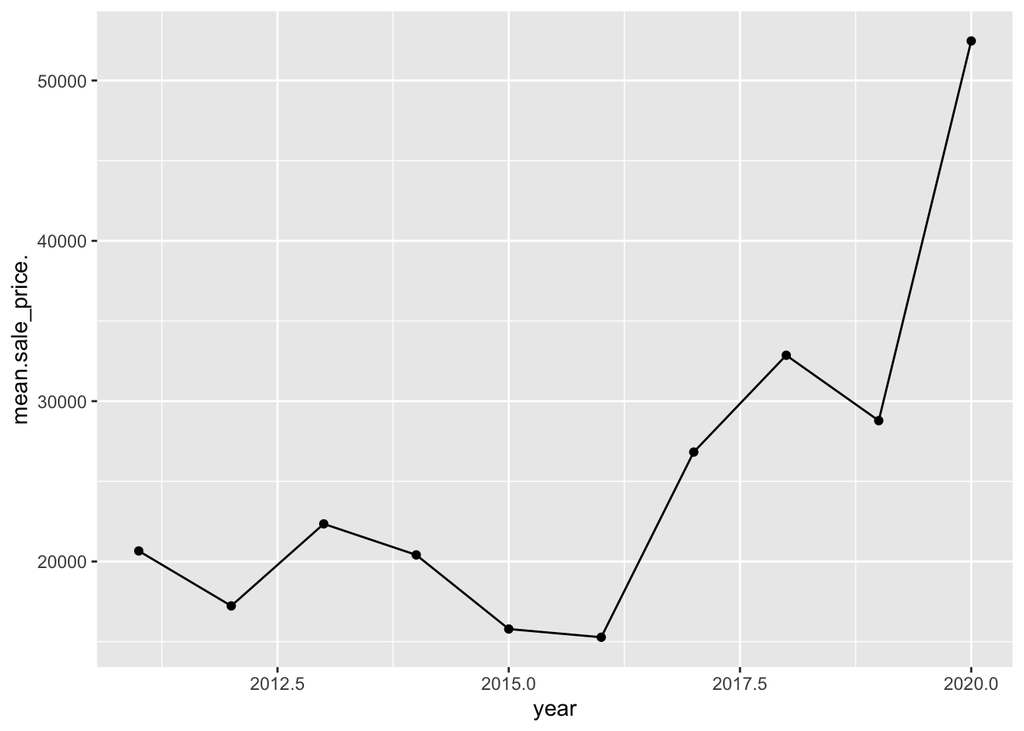

```r
# see the mean, min, max, median of sales_trend
sales_trend <- sales %>%
  group_by(year) %>%
  summarise(mean(sale_price), min(sale_price), max(sale_price), median(sale_price))
# change the database to dataframe
sales_trend <- data.frame(sales_trend)
# see the trend of the mean in sale_price
ggplot(sales_trend, aes(x=year, y=mean.sale_price.)) +
  geom_line() +
  geom_point()
```

Section A - trend of the mean in ASSESSEDCALUE

We can see that the min in ASSESSEDVALUE is 0, this shows that there are outlier values in the data. We can see from the trend plot that the estimated value of Detroit houses has been on a downward trend from 2012 to mid-2017. From mid-2017 to early 2020, it showed a slow growth trend. From the beginning of 2020 to the beginning of 2021, there was a downward trend. However, from the end of 2021 to 2022, there will be a sharp increase.

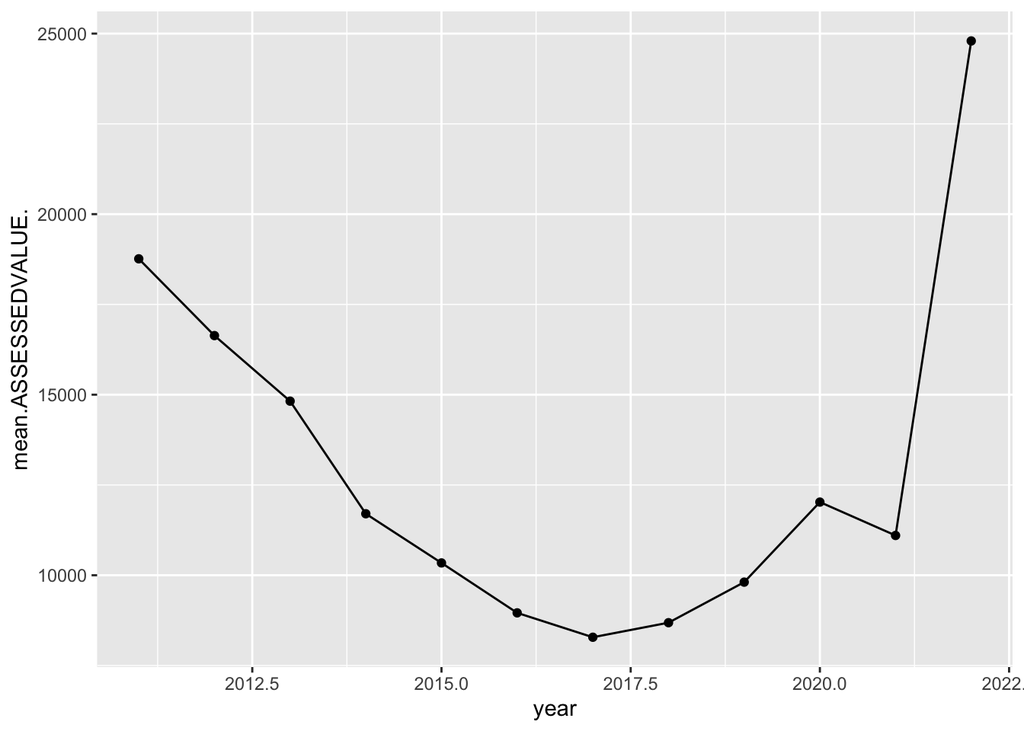

```r
# see the mean, min, max, median of assessments_trend
assessments_trend <- assessments %>%
  group_by(year) %>%
  summarise(mean(ASSESSEDVALUE), min(ASSESSEDVALUE), max(ASSESSEDVALUE), median(ASSESSEDVALUE))
# change the database to dataframe
assessments_trend <- data.frame(assessments_trend)
# see the trend of the mean in ASSESSEDVALUE
ggplot(assessments_trend, aes(x=year, y=mean.ASSESSEDVALUE.)) +
  geom_line() +
  geom_point()
```

Section A - trend of the average value of the estimated value of the house minus the sale price

As can be seen from the trend plot, the average value of the assessed value of the house minus the average price of the house for sale showed a gradual downward trend from 2012 to 2020. This means that the sale price of Detroit houses is higher than the valuation of the houses, and the impact of outlier values on the results cannot be ruled out. Combined with the article, what may happen is that the owners of low-value properties pay too much tax, while the owners of high-value properties pay too little tax.

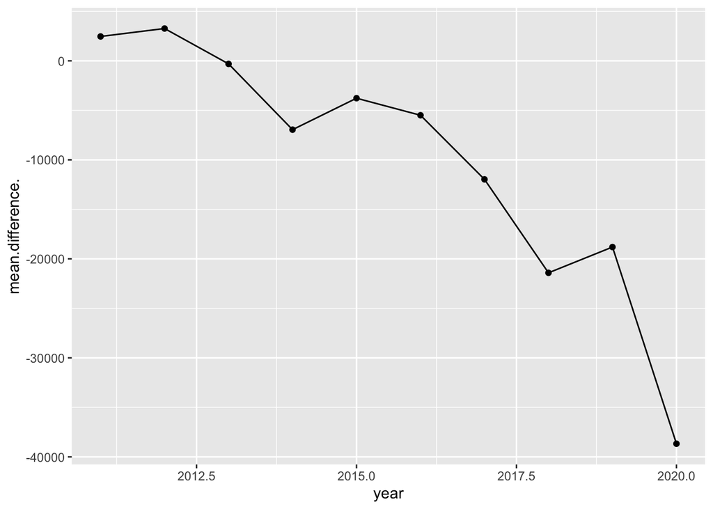

```r
# merge database sales and database assessments
df <- merge(sales, assessments, by.x = c("parcel_num", "year"), by.y = c("PARCELNO", "year"))
# the estimated value of the house minus the sale price
df$difference <- df$ASSESSEDVALUE - df$sale_price
# see the mean of difference_trend
difference_trend <- df %>%
  group_by(year) %>%
  summarise(mean(difference))
# change the database to dataframe
difference_trend <- data.frame(difference_trend)
# see the trend of the mean in difference
ggplot(difference_trend, aes(x=year, y=mean.difference.)) +
  geom_line() +
  geom_point()
```

Section B

The report shows that in Detroit, 48% of the lowest-value houses are overvalued and 5% of the highest-value houses are overvalued. But in my analysis above, the average property price is higher than the average property valuation. If it is as described in the report, then the price of real estate in Detroit is also unreasonable.

```r
devtools::install_github("cmf-uchicago/cmfproperty")
ratios <-
  cmfproperty::reformat_data(
    df,
    sale_col = "sale_price",
    assessment_col = "ASSESSEDVALUE",
    sale_year_col = "year",
  )
```

```
## [1] "Filtered out non-arm's length transactions"
## [1] "Inflation adjusted to 2020"
```

```r
cmfproperty::make_report(ratios,
                         jurisdiction_name = "Detroit",
                         output_dir = "~/Desktop/PA470/Detroit-Part 1/database/")
```

```
##
##
## processing file: report.Rmd
```

[output not shown]

[output not shown]

[output not shown]

[output not shown]

[output not shown]

[output not shown]

[output not shown]

[output not shown]

[output not shown]

```
## output file: report.knit.md
```

[output not shown]

```
##
## Output created: ~/Desktop/PA470/Detroit-Part 1/database//Detroit.html
```

```
## [1] "~~~~~~~~~~~~"
## [1] "geom warnings can be disregarded"
## [1] "Report created at ~/Desktop/PA470/Detroit-Part 1/database//Detroit.html"
```

Section C

From the regression model, we can analyze that there is almost no statistical correlation between the year and house sales, because the p-value is greater than 0.05.

```r
# Explore trends and relationships with property sales using simple regressions
# create new database that just includs year and property sales
sales_total <- dplyr::tbl(con, 'sales') %>% count(year(sale_date)) %>%
  collect()
# change the database to dataframe
sales_total <- data.frame(sales_total)
# simple regression
lm1 <- lm(n ~ year.sale_date., data = sales_total)
summary(lm1)
```

```
##
## Call:
## lm(formula = n ~ year.sale_date., data = sales_total)
##
## Residuals:
##    Min     1Q Median     3Q    Max
## -19036  -4492   2299   6288  12926
##
## Coefficients:
##                  Estimate Std. Error t value Pr(>|t|)
## (Intercept)     1073003.2  2245998.8   0.478    0.646
## year.sale_date.    -518.7     1114.4  -0.465    0.654
##
## Residual standard error: 10120 on 8 degrees of freedom
## Multiple R-squared:  0.02636,    Adjusted R-squared:  -0.09534
## F-statistic: 0.2166 on 1 and 8 DF,  p-value: 0.654
```

We can see from the figure that the sales of houses continued to increase from 2012 to 2014, and reached the highest value in 2014. From 2014 to the beginning of 2016, home sales showed a decreasing trend. From 2016 to mid-2019, home sales showed a slow growth trend. From mid-2019 to 2020, home sales showed a sharp downward trend.

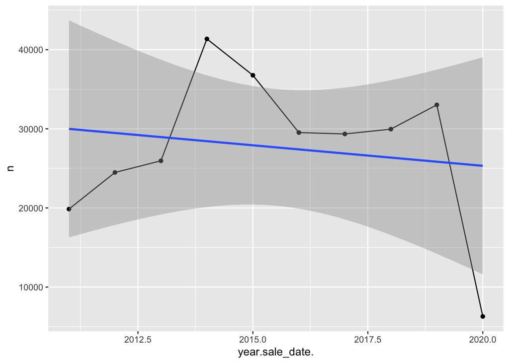

```r
# make a plot
ggplot(sales_total, aes(x=year.sale_date., y=n)) +
  geom_line() +
  geom_point() +
  geom_smooth(formula = y ~ x, method = lm)
```

Section D

From the regression model, we can analyze that there is a slight statistical correlation between years and prophecies, because the p-value is greater than 0.05 but close to 0.05.

```r
# Explore trends and relationships with foreclosures using simple regressions
# create new database that just includs year and foreclosures
foreclosures_total <- colSums(foreclosures[, -c(1 , 2)], na.rm = T)
# change the database to dataframe
foreclosures_total <- data.frame(foreclosures_total)
# change the variable year to numeric
foreclosures_total$year <- as.numeric(row.names(foreclosures_total))
# simple regression
lm2 <- lm(foreclosures_total ~ year, data = foreclosures_total)
summary(lm2)
```

```
##
## Call:
## lm(formula = foreclosures_total ~ year, data = foreclosures_total)
##
## Residuals:
##    Min     1Q Median     3Q    Max
## -12206  -3231  -1139   3404  12346
##
## Coefficients:
##               Estimate Std. Error t value Pr(>|t|)
## (Intercept) -1379996.3   666308.8  -2.071   0.0549 .
## year             690.9      331.4   2.085   0.0535 .
## ---
## Signif. codes:  0 '***' 0.001 '**' 0.01 '*' 0.05 '.' 0.1 ' ' 1
##
## Residual standard error: 7295 on 16 degrees of freedom
## Multiple R-squared:  0.2136, Adjusted R-squared:  0.1645
## F-statistic: 4.346 on 1 and 16 DF,  p-value: 0.05347
```

We can see from the figure that from 2012 to 2015, prophecies showed a gradual growth trend. Although they have fluctuated from time to time, the overall trend is upward. After 2015, it showed a sharp downward trend.

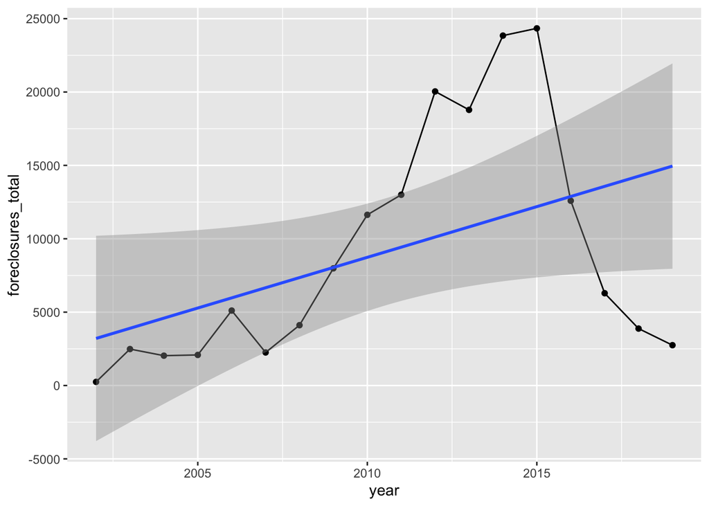

```r
# make a plot
ggplot(foreclosures_total, aes(x=year, y=foreclosures_total)) +
  geom_line() +
  geom_point() +
  geom_smooth(formula = y ~ x, method = lm)
```